# Introduction to Programming

Hugo Lhuillier

Master in Economics, Sciences Po

# Conditional statement

- Logicals (or booleans) are useful to adapt your program to different scenari

```r
x <- 0
if (x > 1) {
  print("x greater than 1")
} else {
  print("x smaller than 1")
}
```

```
## [1] "x smaller than 1"
```

- *Conditional statement*: a statement that might or might not be executed depending on whether a test is true or false

# Conditional statements

- Do not have to include an `else` statement

```r
if (x > 1) {
  print("x greater than 1")
}
```

- Can also add multiple condition

```r
if (x > 1) {
  print("x greater than 1")
} else if (x == 1) {
  print("x equal 1")
} else {
  print("x smaller than 1")
}
```

```
## [1] "x smaller than 1"
```

# Comparisons

- Multiple operators to make logical comparison in `R`
  - `x == y`: returns `TRUE` if $x = y$
  - `x != y`: returns `TRUE` if $x \neq y$
  - `x > y`: returns `TRUE` if $x > y$ (id. for `<`)
  - `x >= y`: returns `TRUE` if $x \geq y$ (id. for `<=`)
- `!` returns the opposite logical:c `!TRUE` returns `FALSE`

# Condition statement: exercice #1

- **Exercice**: write a function `sign` that returns the sign of a numeric

# Condition statement: solution

- **Exercice**: write a function `sign` that returns the sign of a numeric (positive, negative, or zero)

```r
sign <- function(x) {
  if (x > 0) {
    return(1)
  } else if (x == 0) {
    return (0)
  } else {
    return(-1)
  }
}
```

# Condition statement: exercice #2

- **Exercice**: write a function `plot_dist` that plots a boxplot (via `boxplot`) if the length of the vector to be plotted is greater than some threshold, and a stripchart (via `stripchart`) otherwise

# Condition statement: solution

- **Exercice**: write a function `plot_dist` that plots a boxplot (via `boxplot`) if the length of the vector to be plotted is greater than some threshold, and a stripchart (via `stripchart`) otherwise

```r
plot_dist <- function(x, threshold) {
  if (length(x) > threshold) {
    boxplot(x)
  } else {
    stripchart(x)
  }
}
```

# Condition statement: solution

- **Exercice**: write a function `plot_dist` that plots a boxplot (via `boxplot`) if the length of the vector to be plotted is greater than some threshold, and a stripchart (via `stripchart`) otherwise

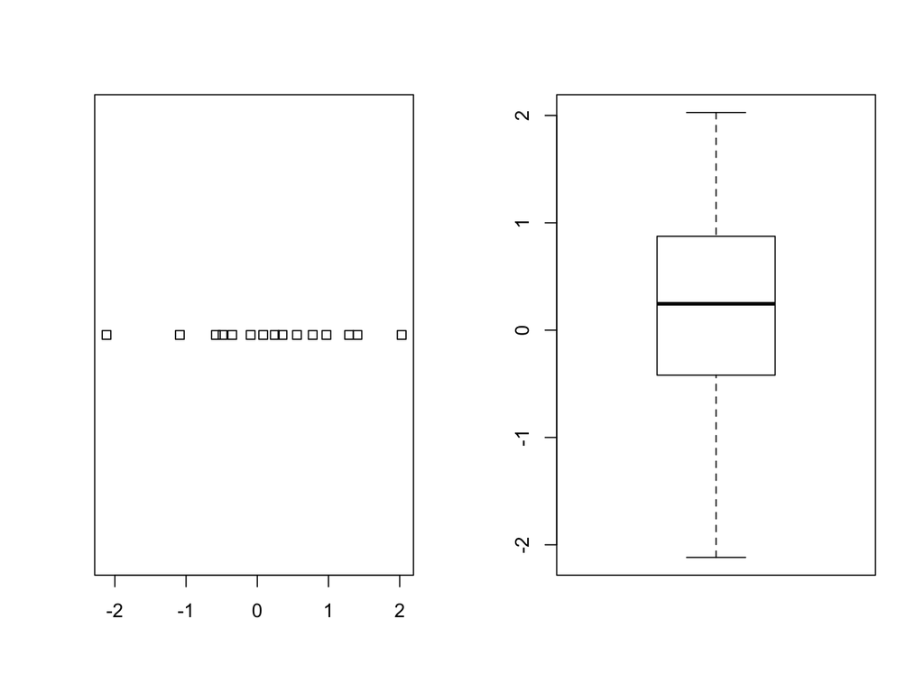

```r
x <- rnorm(15)
par(mfrow=c(1,2))
plot_dist(x, 20)
plot_dist(x, 10)
```

# Multiple conditions

- Can combine conditions, as in maths with the $\cup$ and $\cap$ operators
  - `&` stands for `and` (as $\cap$)
  - `|` stands for `or` (as $\cup$)

```r
x <- 1
if (x > 0 & x < 0) {
  print("this will never print")
}
if (x >= 0 | x <= 0) {
  print("this will always print")
}
```

```
## [1] "this will always print"
```

# Multiple conditions: exercice #3

- **Exercice**: edit the `plot_dist` function to add an additional argument `use_boxplot`; when set to true (default behavior), a large data set will be plotted as a boxplot; otherwise, it will be plotted as a histogram (using `hist()`)

# Multiple conditions: solution

- **Exercice**: edit the `plot_dist` function to add an additional argument `use_boxplot`; when set to true, a large data set will be plotted as a boxplot; otherwise, it will be plotted as a histogram (using `hist()`)

```r
plot_dist <- function(x, threshold, use_boxplot = TRUE) {
   if (length(x) > threshold & use_boxplot) {
       boxplot(x)
   } else if (length(x) > threshold & !use_boxplot) {
       hist(x)
   } else {
       stripchart(x)
   }
}
```

# Multiple conditions: solution

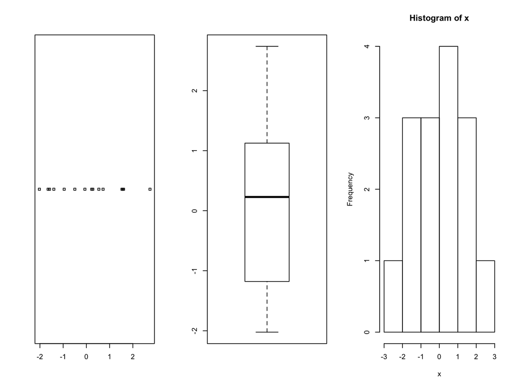

```r
x <- rnorm(15)
par(mfrow=c(1,3))
plot_dist(x, 20)
plot_dist(x, 10)
plot_dist(x, 10, use_boxplot = FALSE)
```